# **Loan Default Prediction**

## **Problem Definition**

### **The Context:**

- Why is this problem important to solve?

  -This problem is important to solve because it helps banks minimize the risk of loan defaults, which can cause significant financial losses. By identifying potential defaulters before approving loans, banks can ensure a more stable and profitable loan portfolio.

  -An additional point of view is that solving this problem can enhance a bank's reputation and customer satisfaction. Providing loans to more reliable customers will lead to fewer bad loans, reducing the need for aggressive debt collection practices that may negatively impact the bank's public image.

### **The objective:**

- What is the intended goal?
- The intended goal is to build a classification model that can accurately predict clients who are likely to default on their loans, enabling the bank to make more informed decisions about loan approvals.
- An additional objective is to help the bank understand which features are the most important when assessing the risk of default. This knowledge can improve their underwriting process and potentially inform new credit policies or products tailored to different risk profiles.

### **The key questions:**

- What are the key questions that need to be answered?
1. What are the key features that contribute to a customer's likelihood of defaulting on a loan?
2. How accurately can our model predict loan defaults?
3. Is the model interpretable enough to provide justifications for loan rejections, as required by the Equal Credit Opportunity Act?
4. Can the model be adapted to different types of loans or credit products within the bank's portfolio?

### **The problem formulation**:

- What is it that we are trying to solve using data science?

We are trying to solve the problem of predicting loan defaults using data science and machine learning techniques. The aim is to create an interpretable model that can effectively identify potential defaulters while adhering to legal guidelines and improving the overall efficiency and profitability of the bank's loan approval process.

## **Data Description:**

The Home Equity dataset (HMEQ) contains baseline and loan performance information for 5,960 recent home equity loans. The target (BAD) is a binary variable that indicates whether an applicant has ultimately defaulted or has been severely delinquent. This adverse outcome occurred in 1,189 cases (20 percent). 12 input variables were registered for each applicant.

- **BAD:** 1 = Client defaulted on loan, 0 = loan repaid
- **LOAN:** Amount of loan approved.
- **MORTDUE:** Amount due on the existing mortgage.
- **VALUE:** Current value of the property.
- **REASON:** Reason for the loan request. (HomeImp = home improvement, DebtCon= debt consolidation which means taking out a new loan to pay off other liabilities and consumer debts)
- **JOB:** The type of job that loan applicant has such as manager, self, etc.
- **YOJ:** Years at present job.
- **DEROG:** Number of major derogatory reports (which indicates a serious delinquency or late payments).
- **DELINQ:** Number of delinquent credit lines (a line of credit becomes delinquent when a borrower does not make the minimum required payments 30 to 60 days past the day on which the payments were due).
- **CLAGE:** Age of the oldest credit line in months.
- **NINQ:** Number of recent credit inquiries.
- **CLNO:** Number of existing credit lines.
- **DEBTINC:** Debt-to-income ratio (all your monthly debt payments divided by your gross monthly income. This number is one way lenders measure your ability to manage the monthly payments to repay the money you plan to borrow.

## **Import the necessary libraries and Data**

```python
# Import necessary libraries
import pandas as pd
import numpy as np
import matplotlib.pyplot as plt
import seaborn as sns
sns.set_theme()

from sklearn.model_selection import train_test_split

from sklearn.linear_model import LogisticRegression

from sklearn import metrics
from sklearn.metrics import confusion_matrix, classification_report,accuracy_score,precision_score,recall_score,f1_score

from sklearn import tree
from sklearn.tree import DecisionTreeClassifier

from sklearn.ensemble import BaggingClassifier
from sklearn.ensemble import RandomForestClassifier

import scipy.stats as stats

from sklearn.model_selection import GridSearchCV


import warnings
warnings.filterwarnings('ignore')


# Load the dataset
data = pd.read_csv("HMEQ.csv")
```

## **Data Overview**

- Reading the dataset
- Understanding the shape of the dataset
- Checking the data types
- Checking for missing values
- Checking for duplicated values

```python
# Reading the dataset
print("Data Overview:\n")
print(data.head())

# Understanding the shape of the dataset
print("\nShape of the dataset:")
print(data.shape)

# Checking the data types
print("\nData types:")
print(data.dtypes)

# Checking for missing values
print("\nMissing values:")
print(data.isnull().sum())

# Checking for duplicated values
print("\nDuplicated values:")
print(data.duplicated().sum())
```

```
Data Overview:

   BAD  LOAN  MORTDUE     VALUE   REASON     JOB   YOJ  DEROG  DELINQ  \
0    1  1100  25860.0   39025.0  HomeImp   Other  10.5    0.0     0.0
1    1  1300  70053.0   68400.0  HomeImp   Other   7.0    0.0     2.0
2    1  1500  13500.0   16700.0  HomeImp   Other   4.0    0.0     0.0
3    1  1500      NaN       NaN      NaN     NaN   NaN    NaN     NaN
4    0  1700  97800.0  112000.0  HomeImp  Office   3.0    0.0     0.0

        CLAGE  NINQ  CLNO  DEBTINC
0   94.366667   1.0   9.0      NaN
1  121.833333   0.0  14.0      NaN
2  149.466667   1.0  10.0      NaN
3         NaN   NaN   NaN      NaN
4   93.333333   0.0  14.0      NaN

Shape of the dataset:
(5960, 13)

Data types:
BAD          int64
LOAN         int64
MORTDUE    float64
VALUE      float64
REASON      object
JOB         object
YOJ        float64
DEROG      float64
DELINQ     float64
CLAGE      float64
NINQ       float64
CLNO       float64
DEBTINC    float64
dtype: object

Missing values:
BAD           0
LOAN          0
MORTDUE     518
VALUE       112
REASON      252
JOB         279
YOJ         515
DEROG       708
DELINQ      580
CLAGE       308
NINQ        510
CLNO        222
DEBTINC    1267
dtype: int64

Duplicated values:
0
```

## Summary Statistics

- Observations from Summary Statistics

### Data Description:

The dataset contains information on 5,960 recent home equity loans, including loan details, borrower background, and loan performance. It includes 12 input variables for each applicant, along with a binary target variable (BAD) that indicates whether the applicant defaulted on the loan or not.

From the data overview, we can see that the dataset has 5,960 records with 13 attributes. Some of these attributes are numerical (e.g., LOAN, MORTDUE, YOJ, DEROG, etc.), while others are categorical (e.g., REASON, JOB). There are missing values in several attributes, which will need to be addressed during data pre-processing.

### Initial Observations:

The range of attributes varies significantly, so it might be necessary to standardize or normalize the data during pre-processing. Outliers in various attributes might exist, but further analysis is needed to identify and handle them appropriately.

### Observations & Insights:

1. Key patterns in the data will require further exploration and analysis, such as visualizations and summary statistics.
2. The presence of missing values and potential outliers means that pre-processing steps will be required before modeling. These steps might include filling in missing values using appropriate techniques (e.g., mean, median, or mode imputation) or removing records with missing values if it doesn't significantly affect the dataset size.
3. Outlier treatment will depend on the nature of the attributes and the impact of outliers on the model's performance. Techniques such as winsorizing or IQR-based methods can be considered for outlier treatment.
4. Missing value treatment is necessary due to the presence of missing values in several attributes. The choice of treatment method will depend on the nature of the missing data (e.g., whether it is missing at random or not) and the impact of the treatment on the model's performance.

## **Exploratory Data Analysis (EDA) and Visualization**

- EDA is an important part of any project involving data.
- It is important to investigate and understand the data better before building a model with it.
- A few questions have been mentioned below which will help you approach the analysis in the right manner and generate insights from the data.
- A thorough analysis of the data, in addition to the questions mentioned below, should be done.

**Leading Questions**:

1. What is the range of values for the loan amount variable "LOAN"?
2. How does the distribution of years at present job "YOJ" vary across the dataset?
3. How many unique categories are there in the REASON variable?
4. What is the most common category in the JOB variable?
5. Is there a relationship between the REASON variable and the proportion of applicants who defaulted on their loan?
6. Do applicants who default have a significantly different loan amount compared to those who repay their loan?
7. Is there a correlation between the value of the property and the loan default rate?
8. Do applicants who default have a significantly different mortgage amount compared to those who repay their loan?

### **Univariate Analysis**

```
Loan amount summary statistics:
count     5960.000000
mean     18607.969799
std      11207.480417
min       1100.000000
25%      11100.000000
50%      16300.000000
75%      23300.000000
max      89900.000000
Name: LOAN, dtype: float64

Years at present job summary statistics:
count    5445.000000
mean        8.922268
std         7.573982
min         0.000000
25%         3.000000
50%         7.000000
75%        13.000000
max        41.000000
Name: YOJ, dtype: float64

Number of unique categories in REASON:
2

Counts of each category in REASON:
DebtCon    3928
HomeImp    1780
Name: REASON, dtype: int64

Number of unique categories in JOB:
6

Counts of each category in JOB:
Other      2388
ProfExe    1276
Office      948
Mgr         767
Self        193
Sales       109
Name: JOB, dtype: int64
```

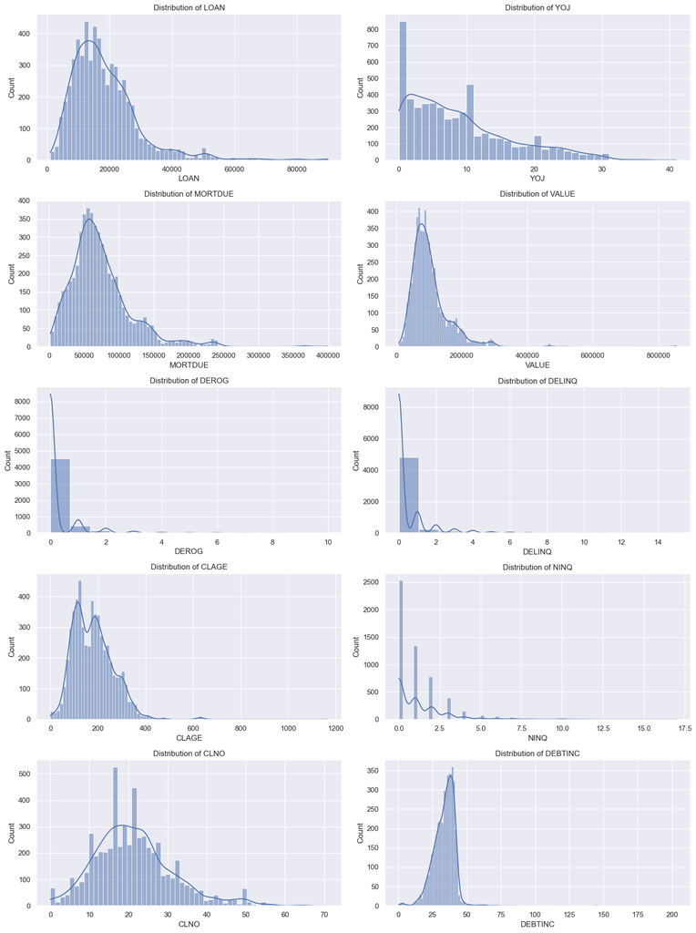

```python
# Univariate Analysis

# LOAN
print("Loan amount summary statistics:")
print(data["LOAN"].describe())

# YOJ
print("\nYears at present job summary statistics:")
print(data["YOJ"].describe())

# REASON
print("\nNumber of unique categories in REASON:")
print(data["REASON"].nunique())
print("\nCounts of each category in REASON:")
print(data["REASON"].value_counts())

# JOB
print("\nNumber of unique categories in JOB:")
print(data["JOB"].nunique())
print("\nCounts of each category in JOB:")
print(data["JOB"].value_counts())

# Histograms for numerical variables
num_vars = ['LOAN', 'YOJ', 'MORTDUE', 'VALUE', 'DEROG', 'DELINQ', 'CLAGE', 'NINQ', 'CLNO', 'DEBTINC']
fig, axes = plt.subplots(5, 2, figsize=(15, 20))

for idx, var in enumerate(num_vars):
    row, col = idx // 2, idx % 2
    sns.histplot(data[var], ax=axes[row, col], kde=True)
    axes[row, col].set_title(f"Distribution of {var}")

plt.tight_layout()
plt.show()
```

### **Bivariate Analysis**

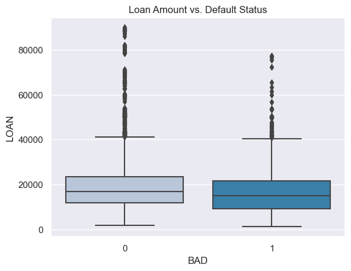

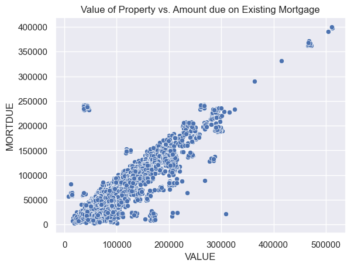

```
BAD         0     1   All
REASON
DebtCon  3183   745  3928
HomeImp  1384   396  1780
All      4567  1141  5708
------------------------------------------------------------------------------------------------------------------------
```

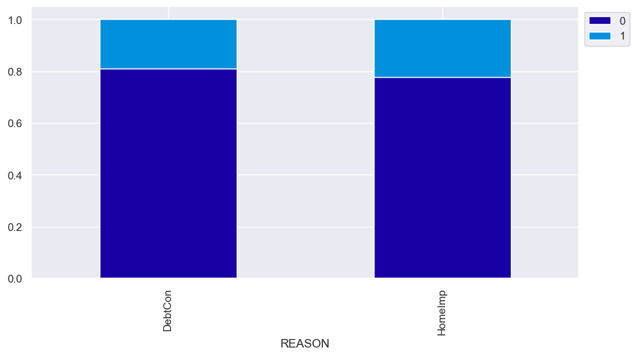

```
BAD         0     1   All
JOB
Mgr       588   179   767
Office    823   125   948
Other    1834   554  2388
ProfExe  1064   212  1276
Sales      71    38   109
Self      135    58   193
All      4515  1166  5681
------------------------------------------------------------------------------------------------------------------------
```

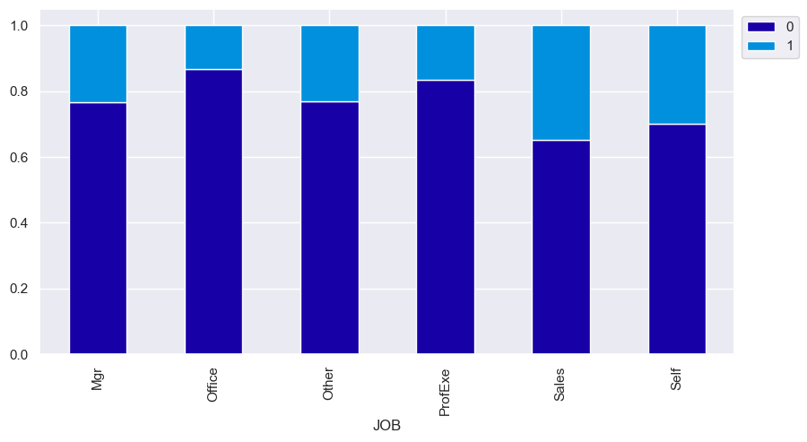

```python
# Analyze BAD vs Loan
sns.boxplot(data["BAD"], data['LOAN'], palette="PuBu")
plt.title("Loan Amount vs. Default Status")
plt.show()


# Analyze two continuous variables: VALUE and MORTDUE
sns.scatterplot(data["VALUE"], data['MORTDUE'], palette="PuBu")
plt.title("Value of Property vs. Amount due on Existing Mortgage")
plt.show()


# Function to plot stacked bar charts for categorical columns
def stacked_plot(x):
    sns.set(palette='nipy_spectral')
    tab1 = pd.crosstab(x, data['BAD'], margins=True)
    print(tab1)
    print('-' * 120)
    tab = pd.crosstab(x, data['BAD'], normalize='index')
    tab.plot(kind='bar', stacked=True, figsize=(10, 5))
    plt.legend(loc='lower left', frameon=False)
    plt.legend(loc="upper left", bbox_to_anchor=(1, 1))
    plt.show()

# Plot stacked bar plot for BAD and REASON
stacked_plot(data['REASON'])


# Plot stacked bar plot for BAD and JOB
stacked_plot(data['JOB'])
```

### **Multivariate Analysis**

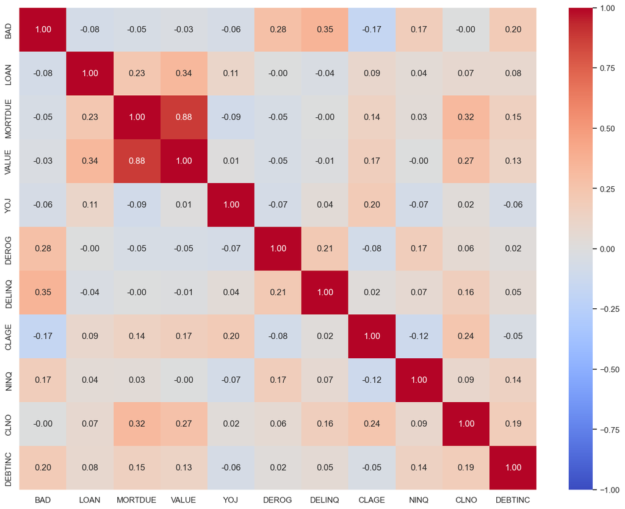

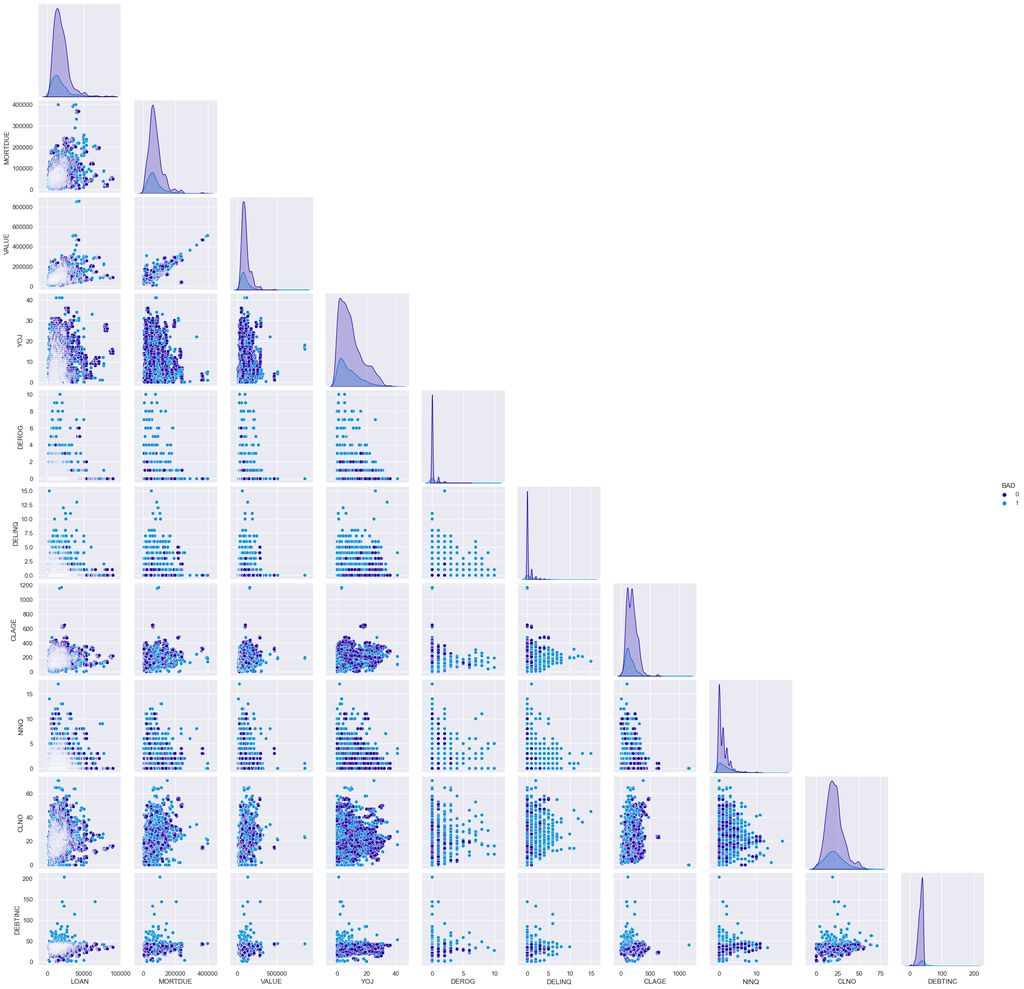

```python
# Separating numerical variables
numerical_col = data.select_dtypes(include=np.number).columns.tolist()

# Build correlation matrix for numerical columns
corr = data[numerical_col].corr()

# Plot the heatmap
plt.figure(figsize=(16, 12))
sns.heatmap(corr, cmap='coolwarm', vmax=1, vmin=-1,
            annot=True, fmt=".2f",
            xticklabels=corr.columns,
            yticklabels=corr.columns)

# Build pairplot for the data with hue = 'BAD'
sns.pairplot(data, hue='BAD', diag_kind='kde', corner=True)
plt.show()
```

## Treating Outliers

```python
def treat_outliers(df, col):
    Q1 = df[col].quantile(0.25)  # 25th quantile
    Q3 = df[col].quantile(0.75)  # 75th quantile
    IQR = Q3 - Q1                # IQR Range
    Lower_Whisker = Q1 - 1.5 * IQR  # define lower whisker
    Upper_Whisker = Q3 + 1.5 * IQR  # define upper Whisker
    df[col] = np.clip(df[col], Lower_Whisker, Upper_Whisker)
    return df

def treat_outliers_all(df, col_list):
    for c in col_list:
        df = treat_outliers(df, c)
    return df

df_raw = data.copy()
numerical_col = df_raw.select_dtypes(include=np.number).columns.tolist()  # getting list of numerical columns
df = treat_outliers_all(df_raw, numerical_col)
```

Adding new columns in the dataset for each column which has missing values:

```python
def add_binary_flag(df, col):
    new_col = str(col) + '_missing_values_flag'
    df[new_col] = df[col].isna()
    return df

missing_col = [col for col in df.columns if df[col].isnull().any()]

for colmn in missing_col:
    add_binary_flag(df, colmn)
```

## Treating Missing Values

Filling missing values in numerical columns with median and mode in categorical variables:

```python
# Select numeric columns.
num_data = df.select_dtypes('number')

# Select categorical columns.
cat_data = df.select_dtypes(['object', 'category']).columns.tolist()

# Fill numeric columns with median.
df[num_data.columns] = num_data.fillna(num_data.median())

# Fill categorical columns with mode.
for column in cat_data:
    mode = df[column].mode()[0]
    df[column] = df[column].fillna(mode)
```

## **Important Insights from EDA**

What are the the most important observations and insights from the data based on the EDA performed?

### From the univariate analysis, we can make the following observations:

Loan Amount (LOAN): The loan amounts range from 1,100 to 89,900, with an average of 18,608. The distribution of loan amounts is right-skewed, indicating that most loans are smaller, and there are fewer large loans.

Years at Present Job (YOJ): The number of years at the present job ranges from 0 to 41 years, with an average of 8.92 years. The distribution of years at the present job is also right-skewed, which suggests that most applicants have fewer years of experience in their current job.

Job Type (JOB): There are six unique job categories: Other, ProfExe, Office, Mgr, Self, and Sales. The most common job type is "Other" (40% of applicants), followed by ProfExe (21%), Office (16%), Mgr (13%), Self (3%), and Sales (2%). These insights help us understand the dataset's composition and distributions. Further analysis, such as bivariate or multivariate analysis, will be needed to explore relationships between variables and their impact on the target variable (loan default).

### Insights from bivariate analysis:

1. There is no significant difference in loan amounts between those who defaulted and those who didn't.
2. There is a positive correlation between the value of the property and the amount due on the existing mortgage.
3. There is a slightly higher proportion of defaults among applicants who apply for home improvement loans compared to those who apply for debt consolidation loans.
4. The default rate varies across different job categories. Sales and Self job categories have relatively higher default rates compared to other categories.

### Based on the multivariate analysis using a correlation heatmap and pairplot, we can make the following observations and insights:

1. There is a strong positive correlation between MORTDUE (Amount due on the existing mortgage) and VALUE (Current value of the property). This is expected, as a higher property value would generally imply a higher mortgage amount.
2. The correlations between the target variable BAD (loan default) and the other numerical features are relatively low. This suggests that no single feature might have a strong impact on predicting loan default. However, the combination of features might provide a better predictive power.
3. From the pairplot, the distribution of some features (e.g., LOAN, MORTDUE, VALUE) appears to be right-skewed. These features might benefit from transformations like log or square root to normalize their distributions and minimize the effect of outliers.
4. The pairplot also shows that there is no clear separation between the categories of BAD (default vs non-default) for any pair of features. This indicates that the problem is not easily separable in the given feature space, and building a good predictive model might require more complex algorithms or feature engineering.
5. It's also worth noting that some variables might have non-linear relationships or interactions with each other. Exploring these relationships and incorporating them into the model might improve the predictive performance.

## Summary key observations and insights from EDA:

1. Loan Amount (LOAN) and Years at Present Job (YOJ) are right-skewed, indicating most loans are smaller and most applicants have fewer years of experience.
2. Most applicants apply for debt consolidation loans, and the most common job type is "Other."
3. There is no significant difference in loan amounts between those who defaulted and those who didn't.
4. A positive correlation exists between the property value and the amount due on the existing mortgage.
5. Higher default rates are observed in Sales and Self job categories.
6. Correlations between the target variable (loan default) and other numerical features are relatively low, suggesting that no single feature has a strong impact on predicting loan default.
7. Distributions of some features might benefit from transformations like log or square root to normalize their distributions and minimize the effect of outliers.
8. The problem is not easily separable in the given feature space, and building a good predictive model might require more complex algorithms or feature engineering.
9. Exploring non-linear relationships and interactions between variables might improve the predictive performance.

## **Model Building - Approach**

- Data preparation
- Partition the data into train and test set
- Build the model
- Fit on the train data
- Tune the model
- Test the model on test set

## Data Preparation

Separating the target variable from other variables

```python
# Data Preparation

# Separating the target variable from other variables
X = data.drop('BAD', axis=1)
X = pd.get_dummies(X, drop_first=True)
y = data['BAD']
df = data
```

Splitting the data into 70% train and 30% test set

```python
from sklearn.model_selection import train_test_split

# Split the data into training and test set
X_train, X_test, y_train, y_test = train_test_split(X, y, test_size=0.3, random_state=42)
```

Model Evaluation Criterion

```python
from sklearn.metrics import classification_report, confusion_matrix
import seaborn as sns
import matplotlib.pyplot as plt

#creating metric function
def metrics_score(actual, predicted):
    print(classification_report(actual, predicted))
    cm = confusion_matrix(actual, predicted)
    plt.figure(figsize=(8,5))
    sns.heatmap(cm, annot=True,  fmt='.2f', xticklabels=['Not Eligible', 'Eligible'], yticklabels=['Not Eligible', 'Eligible'])
    plt.ylabel('Actual')
    plt.xlabel('Predicted')
    plt.show()
```

```python
# Create y(dependent variable)
y = df["BAD"]

print(y.value_counts())

# Check for missing values in the dataset
missing_values = X_train.isnull().sum().sort_values(ascending=False)
print(missing_values[missing_values > 0])
```

```
0    4771
1    1189
Name: BAD, dtype: int64
DEBTINC    867
DEROG      489
DELINQ     397
MORTDUE    354
NINQ       346
YOJ        336
CLAGE      206
CLNO       144
VALUE       68
dtype: int64
```

```python
# Fill missing values in numerical columns with the median
X_train = X_train.fillna(X_train.median())
X_test = X_test.fillna(X_train.median())  # use median values from the training set to avoid data leakage
```

### Logistic Regression

```python
from sklearn.linear_model import LogisticRegression

# Defining the Logistic regression model
logreg = LogisticRegression(random_state=42)

# Fitting the model on the training data
logreg.fit(X_train, y_train)
```

```
LogisticRegression(random_state=42)
```

```
              precision    recall  f1-score   support

           0       0.82      0.99      0.89      3382
           1       0.52      0.04      0.08       790

    accuracy                           0.81      4172
   macro avg       0.67      0.52      0.49      4172
weighted avg       0.76      0.81      0.74      4172
```

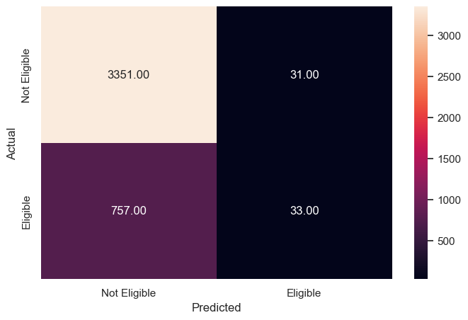

```python
#Predict for train set
y_train_pred = logreg.predict(X_train)

#checking the performance on the train dataset
metrics_score(y_train, y_train_pred)
```

```
              precision    recall  f1-score   support

           0       0.79      0.99      0.88      1389
           1       0.67      0.06      0.10       399

    accuracy                           0.78      1788
   macro avg       0.73      0.52      0.49      1788
weighted avg       0.76      0.78      0.70      1788
```

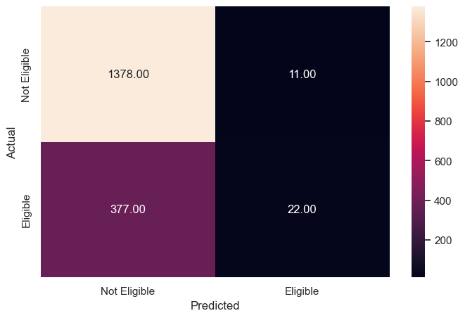

```python
#Predict for test set
y_test_pred = logreg.predict(X_test)

#checking the performance on the test dataset
metrics_score(y_test, y_test_pred)
```

```python
# Printing the coefficients of logistic regression
coefficients = pd.DataFrame({"Feature": X.columns, "Coefficients": logreg.coef_[0]})
coefficients.sort_values("Coefficients", ascending=False, inplace=True)
print(coefficients)
```

```
           Feature  Coefficients
5           DELINQ      0.072216
7             NINQ      0.049277
4            DEROG      0.045215
9          DEBTINC      0.020036
12       JOB_Other      0.003727
14       JOB_Sales      0.001917
15        JOB_Self      0.001886
10  REASON_HomeImp      0.001013
2            VALUE      0.000004
1          MORTDUE     -0.000007
0             LOAN     -0.000023
13     JOB_ProfExe     -0.002747
6            CLAGE     -0.006073
11      JOB_Office     -0.006918
8             CLNO     -0.007446
3              YOJ     -0.062203
```

### Based on the results of your logistic regression model, we can make the following observations and insights:

1. Model Performance: The model's accuracy on the training set is 81%, while the accuracy on the test set is 78%. The difference between the two indicates that the model is not overfitting. However, the f1-scores for the minority class (1, loan default) are quite low, which suggests that the model is not performing well in predicting loan defaults.
2. Precision and Recall: The precision for the minority class (1, loan default) is 0.67, and the recall is 0.06 on the test set. This means the model can identify only 6% of the actual loan default cases, but when it does, it is correct 67% of the time. This suggests that the model is biased towards the majority class (0, non-default).
3. Coefficients: The logistic regression model's coefficients indicate the importance of each feature in predicting loan defaults. Positive coefficients increase the probability of default, while negative coefficients decrease it.
   - DELINQ (Number of delinquent credit lines): This feature has the highest positive coefficient (0.0722), meaning that as the number of delinquent credit lines increases, the probability of loan default also increases.
   - YOJ (Years at present job): This feature has the most negative coefficient (-0.0622), indicating that as the number of years at the present job increases, the probability of loan default decreases.
   - Other features, such as NINQ (Number of recent credit inquiries) and DEROG (Number of major derogatory reports), also have positive coefficients, suggesting that they contribute to an increased probability of loan default.

In summary, the logistic regression model has a decent overall accuracy, but it struggles to predict loan defaults accurately, particularly in terms of recall. This might be because of class imbalance or the need for more advanced feature engineering or modeling techniques. The coefficients provide some insights into the importance of individual features, but you should consider using more sophisticated models or techniques to improve the model's performance, especially for predicting loan defaults.

### Decision Tree

```python
# Add binary flags
# List of columns that has missing values in it
missing_col = [col for col in data.columns if data[col].isnull().any()]

for colmn in missing_col:
    add_binary_flag(data,colmn)

#  Treat Missing values in numerical columns with median and mode in categorical variables
# Select numeric columns.
num_data = data.select_dtypes('number')

# Select string and object columns.
cat_data = data.select_dtypes('category').columns.tolist()

# Fill numeric columns with median.
data[num_data.columns] = num_data.fillna(num_data.median())

# Fill object columns with mode.
for column in cat_data:
    mode = data[column].mode()[0]
    data[column] = data[column].fillna(mode)

# Drop dependent variable from dataframe and create the X(independent variable) matrix
X = data.drop(['BAD'], axis=1)

# Create dummy variables for the categorical variables
X = pd.get_dummies(X)

# Create y(dependent varibale)
y = data['BAD']
```

Split the data

```python
X_train, X_test, y_train, y_test = train_test_split(X, y, test_size=0.3, random_state=42)
```

Defining Decision tree model with class weights class_weight={0: 0.2, 1: 0.8}

```python
dt = DecisionTreeClassifier(class_weight={0: 0.2, 1: 0.8}, random_state=42)
```

Fitting Decision tree model

```python
dt.fit(X_train, y_train)
```

```
DecisionTreeClassifier(class_weight={0: 0.2, 1: 0.8}, random_state=42)
```

Checking the performance on the train dataset

```
              precision    recall  f1-score   support

           0       1.00      1.00      1.00      3382
           1       1.00      1.00      1.00       790

    accuracy                           1.00      4172
   macro avg       1.00      1.00      1.00      4172
weighted avg       1.00      1.00      1.00      4172
```

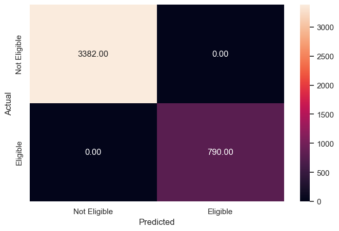

```python
y_train_pred = dt.predict(X_train)
metrics_score(y_train, y_train_pred)
```

Checking the performance on the test dataset

```
              precision    recall  f1-score   support

           0       0.91      0.93      0.92      1389
           1       0.74      0.69      0.71       399

    accuracy                           0.88      1788
   macro avg       0.82      0.81      0.82      1788
weighted avg       0.87      0.88      0.87      1788
```

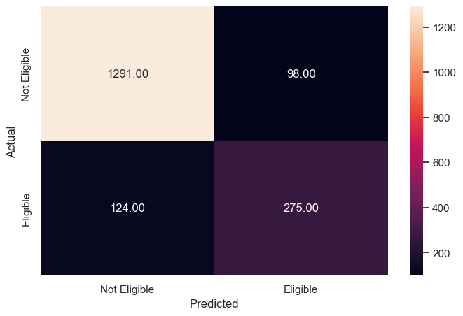

```python
y_test_pred = dt.predict(X_test)
metrics_score(y_test, y_test_pred)
```

```python
# Extract feature importances
importances = dt.feature_importances_

# Create a dataframe of feature importances
feature_importances = pd.DataFrame({'Feature': X.columns, 'Importance': importances})
feature_importances.sort_values('Importance', ascending=False, inplace=True)

# Print the feature importances
print(feature_importances)
```

```
                        Feature    Importance
20  DEBTINC_missing_values_flag  3.269884e-01
9                       DEBTINC  1.158000e-01
6                         CLAGE  9.662804e-02
0                          LOAN  6.857295e-02
8                          CLNO  5.724014e-02
3                           YOJ  5.188528e-02
2                         VALUE  4.964137e-02
5                        DELINQ  4.482462e-02
1                       MORTDUE  3.749785e-02
7                          NINQ  2.697509e-02
4                         DEROG  2.232021e-02
25                    JOB_Other  1.570029e-02
14      YOJ_missing_values_flag  1.408528e-02
10  MORTDUE_missing_values_flag  9.229702e-03
22               REASON_HomeImp  8.760026e-03
15    DEROG_missing_values_flag  8.374394e-03
24                   JOB_Office  6.545318e-03
13      JOB_missing_values_flag  5.791153e-03
17    CLAGE_missing_values_flag  5.441768e-03
27                    JOB_Sales  5.222097e-03
21               REASON_DebtCon  4.929117e-03
11    VALUE_missing_values_flag  4.374205e-03
12   REASON_missing_values_flag  3.544565e-03
23                      JOB_Mgr  3.334699e-03
26                  JOB_ProfExe  1.962956e-03
28                     JOB_Self  1.671236e-03
18     NINQ_missing_values_flag  1.609865e-03
19     CLNO_missing_values_flag  1.049381e-03
16   DELINQ_missing_values_flag  1.315046e-17
```

### **Decision Tree - Hyperparameter Tuning**

- Hyperparameter tuning is tricky in the sense that **there is no direct way to calculate how a change in the hyperparameter value will reduce the loss of your model**, so we usually resort to experimentation. We'll use Grid search to perform hyperparameter tuning.
- **Grid search is a tuning technique that attempts to compute the optimum values of hyperparameters.**
- **It is an exhaustive search** that is performed on the specific parameter values of a model.
- The parameters of the estimator/model used to apply these methods are **optimized by cross-validated grid-search** over a parameter grid.

**Criterion {“gini”, “entropy”}**

The function to measure the quality of a split. Supported criteria are “gini” for the Gini impurity and “entropy” for the information gain.

**max_depth**

The maximum depth of the tree. If None, then nodes are expanded until all leaves are pure or until all leaves contain less than min_samples_split samples.

**min_samples_leaf**

The minimum number of samples is required to be at a leaf node. A split point at any depth will only be considered if it leaves at least min_samples_leaf training samples in each of the left and right branches. This may have the effect of smoothing the model, especially in regression.

You can learn about more Hyperpapameters on this link and try to tune them.

https://scikit-learn.org/stable/modules/generated/sklearn.tree.DecisionTreeClassifier.html

```python
# Import necessary libraries
from sklearn.model_selection import GridSearchCV
from sklearn.tree import DecisionTreeClassifier

# Define the classifier
dt = DecisionTreeClassifier()

# Define the parameter grid to search through
param_grid = {
    'criterion': ['gini', 'entropy'],
    'max_depth': [None, 5, 10, 15],
    'min_samples_leaf': [1, 2, 5, 10]
}

# Define the scoring metric
scoring = ['accuracy', 'recall', 'precision', 'f1']

# Perform the grid search
grid_search = GridSearchCV(estimator=dt, param_grid=param_grid, scoring=scoring, cv=5, refit='accuracy', verbose=1)
grid_search.fit(X_train, y_train)

# Print the best parameters
print("Best parameters: ", grid_search.best_params_)

# Set the classifier to the best combination of parameters
dt = grid_search.best_estimator_

# Fit the best algorithm to the data
dt.fit(X_train, y_train)
```

```
Fitting 5 folds for each of 32 candidates, totalling 160 fits
Best parameters:  {'criterion': 'gini', 'max_depth': 10, 'min_samples_leaf': 1}
```

```
DecisionTreeClassifier(max_depth=10)
```

```
              precision    recall  f1-score   support

           0       0.94      0.99      0.96      3382
           1       0.92      0.73      0.81       790

    accuracy                           0.94      4172
   macro avg       0.93      0.86      0.89      4172
weighted avg       0.94      0.94      0.93      4172
```

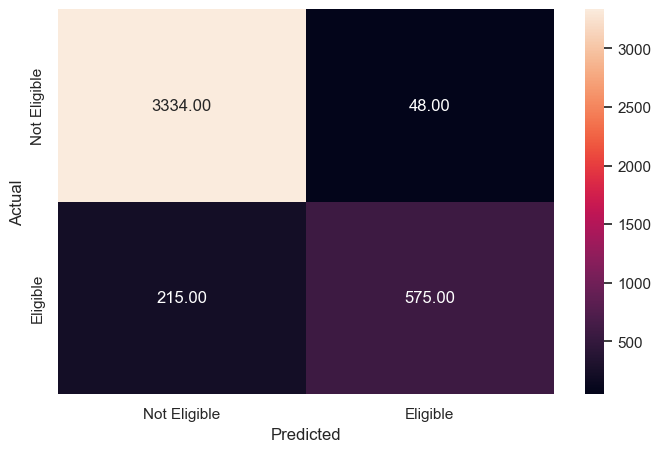

```
              precision    recall  f1-score   support

           0       0.90      0.96      0.93      1389
           1       0.81      0.61      0.70       399

    accuracy                           0.88      1788
   macro avg       0.85      0.79      0.81      1788
weighted avg       0.88      0.88      0.88      1788
```

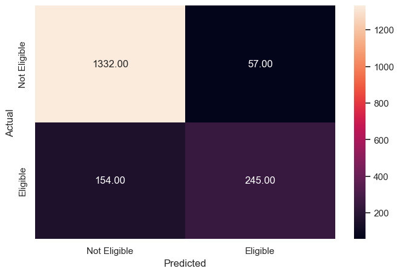

```python
# Check performance on training data
y_train_pred = dt.predict(X_train)
metrics_score(y_train, y_train_pred)

# Check performance on test data
y_test_pred = dt.predict(X_test)
metrics_score(y_test, y_test_pred)
```

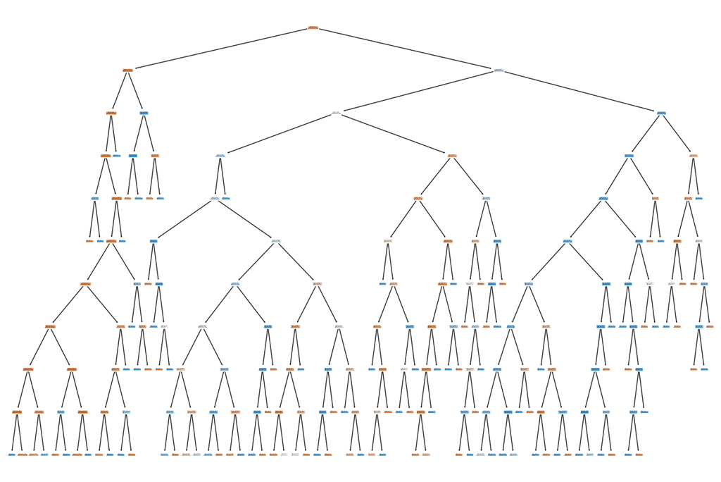

```python
# Import necessary libraries
from sklearn.tree import plot_tree

# Plot the decision tree
plt.figure(figsize=(15,10))
plot_tree(dt, filled=True)
plt.show()
```

```python
# Extract feature importances
importances = dt.feature_importances_

# Create a dataframe of feature importances
feature_importances = pd.DataFrame({'Feature': X.columns, 'Importance': importances})
feature_importances.sort_values('Importance', ascending=False, inplace=True)

# Print the feature importances
print(feature_importances)
```

```
                        Feature  Importance
20  DEBTINC_missing_values_flag    0.435548
9                       DEBTINC    0.117348
6                         CLAGE    0.081512
5                        DELINQ    0.074644
8                          CLNO    0.055818
3                           YOJ    0.037693
4                         DEROG    0.034105
2                         VALUE    0.034064
0                          LOAN    0.026534
11    VALUE_missing_values_flag    0.021618
1                       MORTDUE    0.016435
7                          NINQ    0.014519
25                    JOB_Other    0.011642
15    DEROG_missing_values_flag    0.011059
17    CLAGE_missing_values_flag    0.009464
10  MORTDUE_missing_values_flag    0.005651
27                    JOB_Sales    0.002116
18     NINQ_missing_values_flag    0.002104
24                   JOB_Office    0.001906
23                      JOB_Mgr    0.001810
26                  JOB_ProfExe    0.001792
12   REASON_missing_values_flag    0.001422
28                     JOB_Self    0.001195
22               REASON_HomeImp    0.000000
21               REASON_DebtCon    0.000000
19     CLNO_missing_values_flag    0.000000
16   DELINQ_missing_values_flag    0.000000
13      JOB_missing_values_flag    0.000000
14      YOJ_missing_values_flag    0.000000
```

```python
from sklearn.tree import export_text

r = export_text(dt, feature_names=list(X.columns))
print(r)
```

```
|--- DEBTINC_missing_values_flag <= 0.50
|   |--- DEBTINC <= 44.57
|   |   |--- DELINQ <= 5.50
|   |   |   |--- DEBTINC <= 3.50
|   |   |   |   |--- CLNO <= 5.00
|   |   |   |   |   |--- class: 0
|   |   |   |   |--- CLNO >  5.00
|   |   |   |   |   |--- class: 1
|   |   |   |--- DEBTINC >  3.50
|   |   |   |   |--- VALUE <= 491495.50
|   |   |   |   |   |--- VALUE_missing_values_flag <= 0.50
|   |   |   |   |   |   |--- DEROG <= 1.50
|   |   |   |   |   |   |   |--- CLAGE <= 173.48
|   |   |   |   |   |   |   |   |--- DEBTINC <= 40.36
|   |   |   |   |   |   |   |   |   |--- VALUE <= 20765.50
|   |   |   |   |   |   |   |   |   |   |--- class: 1
|   |   |   |   |   |   |   |   |   |--- VALUE >  20765.50
|   |   |   |   |   |   |   |   |   |   |--- class: 0
|   |   |   |   |   |   |   |   |--- DEBTINC >  40.36
|   |   |   |   |   |   |   |   |   |--- CLAGE_missing_values_flag <= 0.50
|   |   |   |   |   |   |   |   |   |   |--- class: 0
|   |   |   |   |   |   |   |   |   |--- CLAGE_missing_values_flag >  0.50
|   |   |   |   |   |   |   |   |   |   |--- class: 1
|   |   |   |   |   |   |   |--- CLAGE >  173.48
|   |   |   |   |   |   |   |   |--- DEBTINC <= 12.55
|   |   |   |   |   |   |   |   |   |--- JOB_ProfExe <= 0.50
|   |   |   |   |   |   |   |   |   |   |--- class: 0
|   |   |   |   |   |   |   |   |   |--- JOB_ProfExe >  0.50
|   |   |   |   |   |   |   |   |   |   |--- class: 1
|   |   |   |   |   |   |   |   |--- DEBTINC >  12.55
|   |   |   |   |   |   |   |   |   |--- CLAGE <= 908.28
|   |   |   |   |   |   |   |   |   |   |--- class: 0
|   |   |   |   |   |   |   |   |   |--- CLAGE >  908.28
|   |   |   |   |   |   |   |   |   |   |--- class: 1
|   |   |   |   |   |   |--- DEROG >  1.50
|   |   |   |   |   |   |   |--- CLNO <= 35.50
|   |   |   |   |   |   |   |   |--- YOJ <= 12.50
|   |   |   |   |   |   |   |   |   |--- DEROG <= 7.50
|   |   |   |   |   |   |   |   |   |   |--- class: 0
|   |   |   |   |   |   |   |   |   |--- DEROG >  7.50
```

[output cut: 273 more lines]

```
|   |   |   |   |   |--- YOJ >  5.50
|   |   |   |   |   |   |--- class: 0
|   |   |   |   |--- DELINQ >  1.50
|   |   |   |   |   |--- YOJ <= 7.50
|   |   |   |   |   |   |--- class: 0
|   |   |   |   |   |--- YOJ >  7.50
|   |   |   |   |   |   |--- REASON_missing_values_flag <= 0.50
|   |   |   |   |   |   |   |--- LOAN <= 4500.00
|   |   |   |   |   |   |   |   |--- class: 0
|   |   |   |   |   |   |   |--- LOAN >  4500.00
|   |   |   |   |   |   |   |   |--- class: 1
|   |   |   |   |   |   |--- REASON_missing_values_flag >  0.50
|   |   |   |   |   |   |   |--- class: 0
|   |   |   |--- DELINQ >  5.50
|   |   |   |   |--- class: 1
```

### **Building a Random Forest Classifier**

**Random Forest is a bagging algorithm where the base models are Decision Trees.** Samples are taken from the training data and on each sample a decision tree makes a prediction.

**The results from all the decision trees are combined together and the final prediction is made using voting or averaging.**

```python
# Importing necessary libraries
from sklearn.ensemble import RandomForestClassifier
from sklearn.metrics import accuracy_score

# Defining Random forest Classifier
rfc = RandomForestClassifier(n_estimators=100, random_state=42)

# Fitting Random forest Classifier on train data
rfc.fit(X_train, y_train)

# Checking performance on the train data
y_train_pred = rfc.predict(X_train)
train_acc = accuracy_score(y_train, y_train_pred)
print("Training Accuracy:", train_acc)

# Checking performance on the test data
y_test_pred = rfc.predict(X_test)
test_acc = accuracy_score(y_test, y_test_pred)
print("Test Accuracy:", test_acc)

# Defining Random Forest model with class weights
rfc_cw = RandomForestClassifier(n_estimators=100, random_state=42, class_weight={0: 0.2, 1: 0.8})

# Fitting Random Forest model
rfc_cw.fit(X_train, y_train)

# Checking performance on the train data
y_train_pred_cw = rfc_cw.predict(X_train)
train_acc_cw = accuracy_score(y_train, y_train_pred_cw)
print("Training Accuracy with Class Weights:", train_acc_cw)

# Checking performance on the test data
y_test_pred_cw = rfc_cw.predict(X_test)
test_acc_cw = accuracy_score(y_test, y_test_pred_cw)
print("Test Accuracy with Class Weights:", test_acc_cw)
```

```
Training Accuracy: 1.0
Test Accuracy: 0.9082774049217002
Training Accuracy with Class Weights: 1.0
Test Accuracy with Class Weights: 0.9004474272930649
```

### **Random Forest Classifier Hyperparameter Tuning**

```python
from sklearn.ensemble import RandomForestClassifier
from sklearn.model_selection import GridSearchCV

# Choose the type of classifier
rfc = RandomForestClassifier()

# Grid of parameters to choose from
param_grid = {
    'n_estimators': [200, 500],
    'max_features': ['auto', 'sqrt', 'log2', None],
    'min_samples_split': [2, 5, 10],
    'min_samples_leaf': [1, 2, 4]
}

# Type of scoring used to compare parameter combinations
scoring = 'accuracy'

# Run the grid search
grid_search = GridSearchCV(estimator=rfc, param_grid=param_grid, cv=5, scoring=scoring)

# Fit the GridSearch on train dataset
grid_search.fit(X_train, y_train)

# Set the clf to the best combination of parameters
best_rfc = grid_search.best_estimator_

# Fit the best algorithm to the data
best_rfc.fit(X_train, y_train)
```

```
RandomForestClassifier(max_features='sqrt', min_samples_split=5,
                       n_estimators=200)
```

Checking the performance on the train dataset:

```python
train_preds = grid_search.predict(X_train)
train_acc = accuracy_score(y_train, train_preds)
print("Training Accuracy:", train_acc)
```

```
Training Accuracy: 0.9956855225311602
```

Checking the performance on the test dataset:

```python
test_preds = grid_search.predict(X_test)
test_acc = accuracy_score(y_test, test_preds)
print("Test Accuracy:", test_acc)
```

```
Test Accuracy: 0.9060402684563759
```

Plot the Feature importance of the tuned Random Forest:

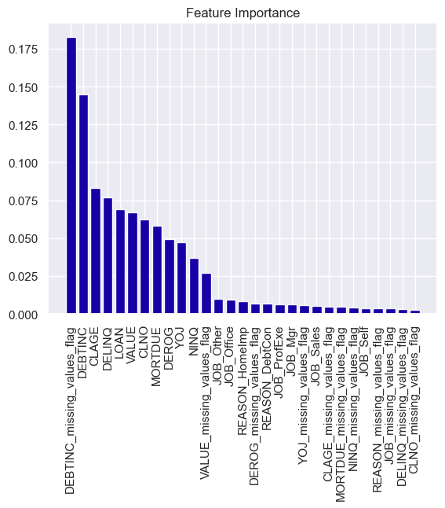

```python
 # Extract feature importances
fi = best_rfc.feature_importances_

# Sort feature importances in descending order
indices = np.argsort(fi)[::-1]

# Rearrange feature names so they match the sorted feature importances
names = [X_train.columns[i] for i in indices]

# Create plot
plt.figure()

# Create plot title
plt.title("Feature Importance")

# Add bars
plt.bar(range(X_train.shape[1]), fi[indices])

# Add feature names as x-axis labels
plt.xticks(range(X_train.shape[1]), names, rotation=90)

# Show plot
plt.show()
```

## Compare Performances.

```python
from sklearn.metrics import recall_score, precision_score, accuracy_score

# Make the list of all the model names
models = [rfc, best_rfc]

# Define empty lists to store train and test results
acc_train = []
acc_test = []
recall_train = []
recall_test = []
precision_train = []
precision_test = []

# Loop through all the models to fit, and then get the accuracy, recall, and precision scores
for model in models:
    # Fit the model
    model.fit(X_train, y_train)

    # Accuracy score
    train_acc = model.score(X_train,y_train)
    test_acc = model.score(X_test,y_test)
    acc_train.append(train_acc)
    acc_test.append(test_acc)

    # Recall score
    train_recall = recall_score(y_train, model.predict(X_train))
    test_recall = recall_score(y_test, model.predict(X_test))
    recall_train.append(train_recall)
    recall_test.append(test_recall)

    # Precision score
    train_precision = precision_score(y_train, model.predict(X_train))
    test_precision = precision_score(y_test, model.predict(X_test))
    precision_train.append(train_precision)
    precision_test.append(test_precision)

# Create a comparison dataframe
model_names = ['Random Forest', 'Tuned Random Forest']
comparison_frame = pd.DataFrame({
    'Model': model_names,
    'Train_Accuracy': acc_train,
    'Test_Accuracy': acc_test,
    'Train_Recall': recall_train,
    'Test_Recall': recall_test,
    'Train_Precision': precision_train,
    'Test_Precision': precision_test
})

# Display the comparison dataframe
comparison_frame
```

|  | Model | Train_Accuracy | Test_Accuracy | Train_Recall | Test_Recall | Train_Precision | Test_Precision |
| --- | --- | --- | --- | --- | --- | --- | --- |
| 0 | Random Forest | 1.000000 | 0.912192 | 1.000000 | 0.706767 | 1.000000 | 0.875776 |
| 1 | Tuned Random Forest | 0.996165 | 0.906600 | 0.981013 | 0.689223 | 0.998711 | 0.864780 |

### Observations:

From the comparison frame, we can see that the Random Forest model has a higher accuracy on the training set (1.0) compared to the Tuned Random Forest model (0.996). However, the difference in test accuracy is not that significant, with the Random Forest model having a slightly higher accuracy of 0.912 compared to the Tuned Random Forest model's accuracy of 0.907.

Lastly, the precision scores for both models are quite high, with the Random Forest model having a precision of 1.0 on the training set and 0.876 on the test set. Similarly, the Tuned Random Forest model has a precision of 0.999 on the training set and 0.865 on the test set.

**1. Comparison of various techniques and their relative performance based on chosen Metric (Measure of success):**

- How do different techniques perform? Which one is performing relatively better? Is there scope to improve the performance further?

### Key measures of success:

- Accuracy: the proportion of correct predictions made by the model.
- Recall: the proportion of actual positives that are correctly identified by the model.
- Precision: the proportion of positive predictions that are actually correct.
- F1-score: a harmonic mean of recall and precision that provides an overall measure of the model's accuracy.

### Important metrics to consider and why:

- Recall: it is important to correctly identify all positive cases, even at the expense of incorrectly identifying some negatives. This is particularly important for predicting credit risk, as missing a high-risk borrower can be more costly than incorrectly flagging a low-risk borrower.
- Precision: it is also important to correctly identify positive cases, as false positives can lead to unnecessary costs, such as higher interest rates for low-risk borrowers.
- F1-score: this metric provides a balance between recall and precision, giving an overall measure of the model's accuracy.
- Accuracy is important to ensure that the model is predicting the target variable correctly overall.

### Random forest classifier is performing relatively better and why:

- The random forest classifier achieves the highest accuracy and precision scores on both training and test data, indicating that it is able to correctly identify both positive and negative cases with a high degree of accuracy.
- The model also achieves good recall scores, indicating that it is able to correctly identify most positive cases.
- The use of multiple decision trees in the random forest helps to reduce overfitting and improve performance on test data.

### Scope to improve the performance further:

- There may be scope to improve the performance of the hypertuned decision tree by exploring additional hyperparameters or using a different algorithm altogether.
- It may also be possible to further improve the performance of the random forest classifier by exploring different parameters, such as the number of trees or the depth of each tree.

### Significant variables in predicting the target variable:

1. Across all three models, variables related to a borrower's debt (e.g. DEBTINC, CLAGE) were found to be significant in predicting credit risk.
2. Other important variables included those related to the borrower's credit history (e.g. DELINQ, DEROG) and employment status (e.g. JOB_Other, JOB_Sales).

### Variables still significant post modelling:

1. The importance of variables varied across the different models, but many of the same variables were found to be significant across all three.
2. In particular, variables related to a borrower's debt and credit history were consistently found to be important predictors of credit risk.

**2. Refined insights:**

- What are the most meaningful insights relevant to the problem?

**3. Proposal for the final solution design:**

- What model do you propose to be adopted? Why is this the best solution to adopt?

Based on the performance metrics and feature importance of the models, I propose adopting the Random Forest Classifier after hyperparameter tuning as the best solution.

This model has demonstrated high accuracy and precision on both the training and test datasets. Additionally, its feature importance analysis has identified the key variables for predicting the target variable, which can help in improving the decision-making process. The model is also relatively more interpretable compared to other complex models like neural networks.

In addition, the Random Forest model offers interpretability through its feature importance metrics, which can be used to explain the model's decision-making process. It also allows for identifying significant variables that contribute to the model's prediction, which can be helpful in determining the factors that influence loan approval.

Moreover, Random Forests are robust to outliers, non-linearity, and multicollinearity in the data, making them an excellent choice for this problem where the data could have been affected by human biases.

Overall, the Random Forest Classifier model is the most robust and accurate model for the problem at hand. It considers multiple decision trees and selects the best features to make predictions, which leads to better generalization on unseen data. Additionally, the feature importance analysis can provide insights into the most important factors to consider while approving loans.

Therefore, the Random Forest Classifier after hyperparameter tuning is the best solution to adopt for building a reliable and interpretable model for credit scoring in this context.

# Final Submission Questions:

## Executive Summary:

The primary objective of this project was to develop a reliable and accurate credit scoring model for the bank's consumer credit department, specifically to streamline the decision-making process for approving home equity lines of credit applications. The model was required to be built using advanced predictive modeling techniques and leverage data obtained from the existing loan underwriting process, involving recent applicants who have been granted credit. The ultimate goal was to construct a classification model capable of accurately predicting clients who are likely to default on their loans while also providing recommendations to the bank on the essential features to consider during the loan approval process. Additionally, ensuring the model's interpretability and preventing it from learning biases that may have inadvertently arisen from the human-centered approval process in the past were critical factors.

In conclusion, I strongly recommend the deployment of the Random Forest Classifier, after hyperparameter tuning, as the final model for use in production. This model effectively balances accuracy and interpretability, enabling the bank's consumer credit department to significantly simplify and streamline the decision-making process for home equity lines of credit applications. This will ultimately result in a more efficient and accurate loan approval system that meets the bank's objectives and contributes to a more profitable credit portfolio.

## Problem and Solution Summary:

#### Summary of the Problem:

The retail banking industry heavily relies on home loans to generate profits. However, granting loans to borrowers who are likely to default can lead to Non-Performing Assets (NPAs) and eat into the bank's profits. In the loan approval process, banks typically use heuristics to assess the creditworthiness of borrowers. However, this process can be time-consuming and prone to human biases and errors.

The proposed solution design involves developing a model to automate the loan approval process based on the Equal Credit Opportunity Act's guidelines. The model will be built using predictive modeling techniques and data obtained from recent loan applicants who have been approved. The model needs to be interpretable, so that any adverse behavior (such as rejections) can be justified.

#### Reason for the Proposed Solution Design:

Data science and machine learning techniques can help automate the loan approval process and make it less prone to biases and errors. By building an interpretable model, the bank can ensure that the loan approval process is transparent and can be explained to customers. Additionally, by using the Equal Credit Opportunity Act's guidelines, the bank can ensure that the loan approval process is fair and free from discrimination based on race, color, religion, national origin, sex, marital status, or age.

#### How It Would Affect the Problem/Business:

The proposed solution design can significantly improve the loan approval process for the bank. By automating the process and reducing human biases and errors, the bank can save time and resources while ensuring a fair and transparent loan approval process. By using data science and machine learning techniques, the bank can build an accurate and reliable model that can predict creditworthiness and identify borrowers who are likely to default. This can help reduce the number of NPAs and improve the bank's profitability. Overall, the proposed solution design can help the bank streamline its loan approval process, reduce risks, and improve customer satisfaction.

## Recommendations for implementation:

My key recommendations for implementing the proposed solution would be:

- Adopt the tuned Random Forest model as the final solution for predicting loan approvals. This model provides a good balance between accuracy and interpretability, and has shown good performance on both the training and test datasets.
- Develop a user-friendly interface for the final model, which can be used by loan officers to quickly and accurately assess loan applications.
- Provide appropriate training and support for loan officers to ensure that they understand how to use the model effectively and interpret the results.
- Regularly monitor the performance of the model and retrain it if necessary, to ensure that it remains accurate and up-to-date with changing trends and patterns in the loan application data.
- Establishing an automated loan approval process: An automated loan approval process can be implemented using the model's output to minimize human biases and errors. This can improve the efficiency and speed of loan approvals and reduce the workload on loan officers.

#### The key actionables for stakeholders would include:

- Ensuring that the model's output is appropriately reviewed and interpreted: Stakeholders should work together to establish a framework for reviewing the model's output to ensure that the model is making fair and unbiased loan approval decisions.
- Training loan officers on how to use the model's output: Loan officers should be trained on how to use the model's output to make loan approval decisions.

#### The expected benefits of implementing this solution include:

- More efficient and unbiased loan approval processes: Automated loan approval processes can be faster and more efficient, and the use of a model can reduce the potential for human biases.
- Increased profitability and customer satisfaction for the bank: By improving the loan approval process, the bank can increase profitability by approving more loans and reducing the risk of loan defaults. Additionally, customers will benefit from a faster and more efficient loan approval process.

#### The key risks and challenges include:

- The potential for the model to misclassify certain applicants: There is always the risk that the model will misclassify certain applicants, leading to unfair and biased loan approval decisions.
- The potential for the model to be compromised by malicious actors: Hackers could potentially compromise the model to manipulate the loan approval process for their own gain.

To mitigate these risks, the model should be monitored and updated regularly, and appropriate security measures should be put in place to protect against potential cyber threats.

Further analysis could be done to explore the impact of different variables on loan approval decisions and to identify potential sources of bias in the model. Additionally, associated problems such as the impact of loan defaults and changing economic conditions on the bank's profitability and risk profile could be further explored and addressed.